#### $Machine Learning Project - Exercise Band$

#### Introduction

This report presents an analysis of a *FitBit-like* device used to monitor a specific exercise routine. Data is stored from the on-device accelerometer, when placed at three positions on the participants’ body: belt, forearm and arm. An extra placement is recorded on the equipment-type used.

#### Data

The data for this assignment is from [this location](http://groupware.les.inf.puc-rio.br/har), and contains information from the placement accelerometers. The data will be split into a training and testing groups.

#### Method

Set the libraries and read the training test file. Split input training data into training and testing

Load data to memory

Split the training data at the 90% point

```r
inTrain <- createDataPartition(y=pml.training$classe, p=0.9, list=FALSE)
newTraining <- pml.training[inTrain,]
newTesting <- pml.training[-inTrain,]
```

#### Cleaning the data

Clean the data of NAs with the following process:

Mod 1: Cleaning NearZeroVariance Variables

(from Help - *nearZeroVar* diagnoses predictors that have one unique value (i.e. are zero variance predictors) or predictors that are have both of the following characteristics: they have very few unique values relative to the number of samples and the ratio of the frequency of the most common value to the frequency of the second most common value is large. checkConditionalX looks at the distribution of the columns of x conditioned on the levels of y and identifies columns of x that are sparse within groups of y.)

Inspect possible Non-Zero Variables:

```r
myDataNZV <- nearZeroVar(newTraining, saveMetrics=TRUE)
```

```
## [1] 17662   100
```

Mod 2: remove first column of training (ID) Removing the variable (ID) so that it doesn’t interfer with ML

```r
newTraining <- newTraining[c(-1)]
```

Mod 3: Cleaning variables of too many NAs. For Variables that have >60% threshold of NA’s

```
## [1] 17662    58
```

adjust newTesting and testing data as above

```r
cleanUp1 <- colnames(newTraining)
cleanUp2 <- colnames(newTraining[, -58]) #already with classe column removed
newTesting <- newTesting[cleanUp1]
testing <- testing[cleanUp2]

#To check the new observations
dim(newTesting)
```

```
## [1] 1960   58
```

```r
#To check the new observations
dim(testing)
```

```
## [1] 19622    57
```

```r
#The last column (problem_id) which is not equal to training sets, was removed
```

```r
#show names, summary of training, write the summary to a file
names(newTraining)
```

```
##  [1] "user_name"            "raw_timestamp_part_1" "raw_timestamp_part_2"
##  [4] "cvtd_timestamp"       "num_window"           "roll_belt"
##  [7] "pitch_belt"           "yaw_belt"             "total_accel_belt"
## [10] "gyros_belt_x"         "gyros_belt_y"         "gyros_belt_z"
## [13] "accel_belt_x"         "accel_belt_y"         "accel_belt_z"
## [16] "magnet_belt_x"        "magnet_belt_y"        "magnet_belt_z"
## [19] "roll_arm"             "pitch_arm"            "yaw_arm"
## [22] "total_accel_arm"      "gyros_arm_x"          "gyros_arm_y"
## [25] "gyros_arm_z"          "accel_arm_x"          "accel_arm_y"
## [28] "accel_arm_z"          "magnet_arm_x"         "magnet_arm_y"
## [31] "magnet_arm_z"         "roll_dumbbell"        "pitch_dumbbell"
## [34] "yaw_dumbbell"         "total_accel_dumbbell" "gyros_dumbbell_x"
## [37] "gyros_dumbbell_y"     "gyros_dumbbell_z"     "accel_dumbbell_x"
## [40] "accel_dumbbell_y"     "accel_dumbbell_z"     "magnet_dumbbell_x"
## [43] "magnet_dumbbell_y"    "magnet_dumbbell_z"    "roll_forearm"
## [46] "pitch_forearm"        "yaw_forearm"          "total_accel_forearm"
## [49] "gyros_forearm_x"      "gyros_forearm_y"      "gyros_forearm_z"
## [52] "accel_forearm_x"      "accel_forearm_y"      "accel_forearm_z"
## [55] "magnet_forearm_x"     "magnet_forearm_y"     "magnet_forearm_z"
## [58] "classe"
```

```r
smt <- summary(newTraining)
write.table(smt, file="K:/COURSES/JHU_DataScience/PracticalMachineLearning/project/data/summary.txt", sep=',')
```

```r
ptm <- proc.time()
modFitA1 <- train(classe ~ user_name + pitch_arm + yaw_arm + roll_arm + roll_belt + pitch_belt + yaw_belt + gyros_belt_x + gyros_belt_y + gyros_belt_z + accel_belt_x + accel_belt_y + accel_belt_z + magnet_belt_x + magnet_belt_y + magnet_belt_z + gyros_arm_x + gyros_arm_y + gyros_arm_z + accel_arm_x + accel_arm_y + accel_arm_z + magnet_arm_x + magnet_arm_y + magnet_arm_z + roll_dumbbell + pitch_dumbbell + yaw_dumbbell, method="gbm", data=newTraining, verbose=FALSE)
```

training time

```r
tm <- proc.time() - ptm
tm
```

```
##    user  system elapsed
## 1288.45    3.62 1454.29
```

```r
ptm <- proc.time()
modFitA2 <- train(classe ~ user_name + pitch_arm + yaw_arm + roll_arm + roll_belt + pitch_belt + yaw_belt + gyros_belt_x + gyros_belt_y + gyros_belt_z + accel_belt_x + accel_belt_y + accel_belt_z + magnet_belt_x + magnet_belt_y + magnet_belt_z + gyros_arm_x + gyros_arm_y + gyros_arm_z + accel_arm_x + accel_arm_y + accel_arm_z + magnet_arm_x + magnet_arm_y + magnet_arm_z + roll_dumbbell + pitch_dumbbell + yaw_dumbbell, method="gbm", data=newTesting, verbose=FALSE)
```

testing time

```r
tm <- proc.time() - ptm
tm
```

```
##    user  system elapsed
##  134.30    0.31  162.23
```

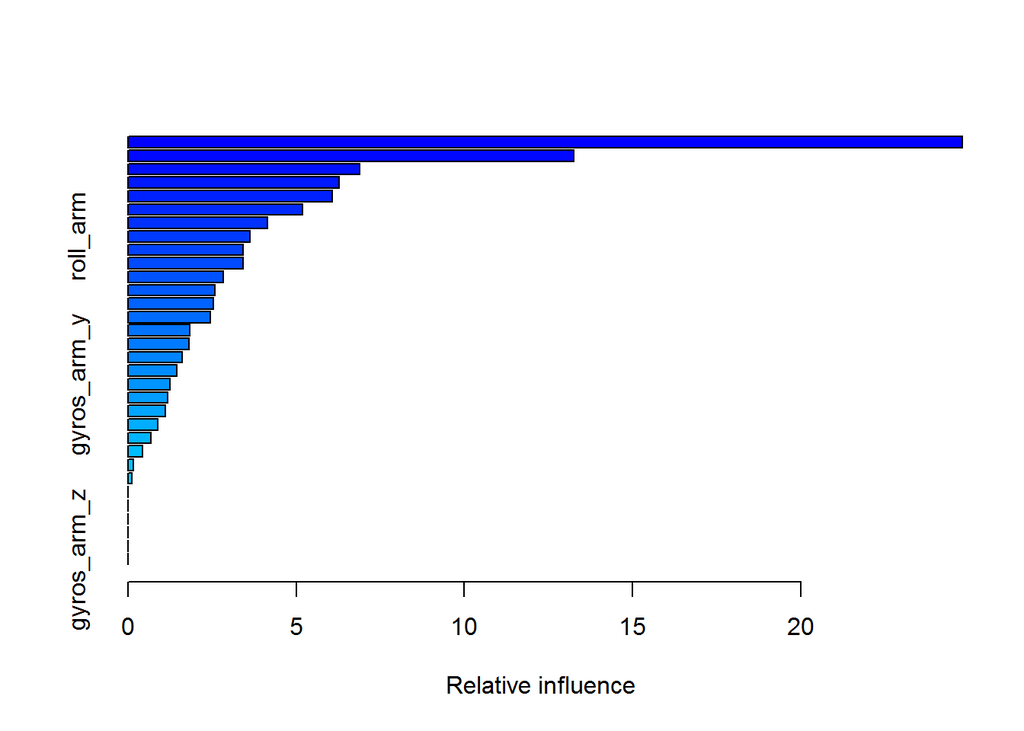

```
##                                 var    rel.inf
## roll_belt                 roll_belt 24.8004549
## yaw_belt                   yaw_belt 13.2581575
## magnet_belt_z         magnet_belt_z  6.8879286
## roll_dumbbell         roll_dumbbell  6.2670735
## pitch_belt               pitch_belt  6.0828479
## magnet_arm_x           magnet_arm_x  5.1978168
## magnet_arm_z           magnet_arm_z  4.1531520
## roll_arm                   roll_arm  3.6326962
## gyros_belt_z           gyros_belt_z  3.4184291
## accel_arm_x             accel_arm_x  3.4133532
## user_nameeurico     user_nameeurico  2.8309509
## yaw_dumbbell           yaw_dumbbell  2.5753052
## pitch_dumbbell       pitch_dumbbell  2.5310924
## accel_arm_z             accel_arm_z  2.4527768
## yaw_arm                     yaw_arm  1.8361944
## accel_belt_z           accel_belt_z  1.8160015
## magnet_belt_x         magnet_belt_x  1.6058697
## pitch_arm                 pitch_arm  1.4446081
## gyros_arm_y             gyros_arm_y  1.2518722
## magnet_belt_y         magnet_belt_y  1.1788608
## magnet_arm_y           magnet_arm_y  1.1150757
## user_namecharles   user_namecharles  0.8853653
## gyros_belt_y           gyros_belt_y  0.6747000
## gyros_arm_x             gyros_arm_x  0.4252966
## accel_arm_y             accel_arm_y  0.1545834
## gyros_belt_x           gyros_belt_x  0.1095373
## user_namecarlitos user_namecarlitos  0.0000000
## user_namejeremy     user_namejeremy  0.0000000
## user_namepedro       user_namepedro  0.0000000
## accel_belt_x           accel_belt_x  0.0000000
## accel_belt_y           accel_belt_y  0.0000000
## gyros_arm_z             gyros_arm_z  0.0000000
```

```r
#predict training
summary(modFitA1)
```

```r
predictTraining <- predict(modFitA1, newTraining)
table(predictTraining, newTraining$classe)
```

```
##
## predictTraining    A    B    C    D    E
##               A 4725  151   56   47   36
##               B   87 3128  125   17   33
##               C   57  117 2830  129   23
##               D  113   10   62 2679   18
##               E   40   12    7   23 3137
```

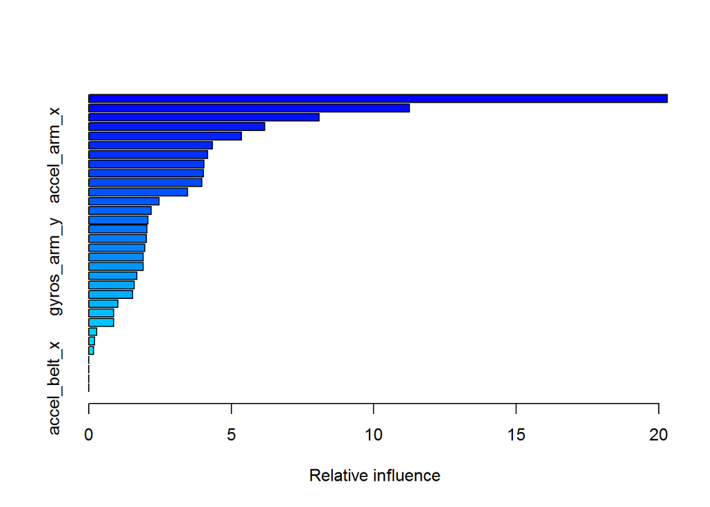

```
##                                 var    rel.inf
## roll_belt                 roll_belt 20.2945582
## yaw_belt                   yaw_belt 11.2603480
## roll_dumbbell         roll_dumbbell  8.0878723
## pitch_belt               pitch_belt  6.1718943
## magnet_belt_z         magnet_belt_z  5.3493030
## yaw_arm                     yaw_arm  4.3351289
## accel_arm_x             accel_arm_x  4.1733592
## magnet_arm_z           magnet_arm_z  4.0399129
## pitch_dumbbell       pitch_dumbbell  4.0193920
## magnet_arm_x           magnet_arm_x  3.9627574
## gyros_belt_z           gyros_belt_z  3.4699891
## magnet_arm_y           magnet_arm_y  2.4762284
## roll_arm                   roll_arm  2.1975738
## pitch_arm                 pitch_arm  2.0843119
## accel_arm_z             accel_arm_z  2.0346517
## magnet_belt_y         magnet_belt_y  2.0290223
## yaw_dumbbell           yaw_dumbbell  1.9648800
## user_nameeurico     user_nameeurico  1.9048732
## gyros_arm_y             gyros_arm_y  1.9023023
## magnet_belt_x         magnet_belt_x  1.6857479
## gyros_arm_x             gyros_arm_x  1.6000038
## accel_arm_y             accel_arm_y  1.5463860
## accel_belt_z           accel_belt_z  1.0177495
## gyros_belt_x           gyros_belt_x  0.8740361
## gyros_belt_y           gyros_belt_y  0.8646887
## user_namepedro       user_namepedro  0.2764315
## accel_belt_y           accel_belt_y  0.2126767
## gyros_arm_z             gyros_arm_z  0.1639205
## user_namecarlitos user_namecarlitos  0.0000000
## user_namecharles   user_namecharles  0.0000000
## user_namejeremy     user_namejeremy  0.0000000
## accel_belt_x           accel_belt_x  0.0000000
```

```r
summary(modFitA2,n.trees=150)
```

A plot of these top two features colored by outcome demonstrates their relative importance.

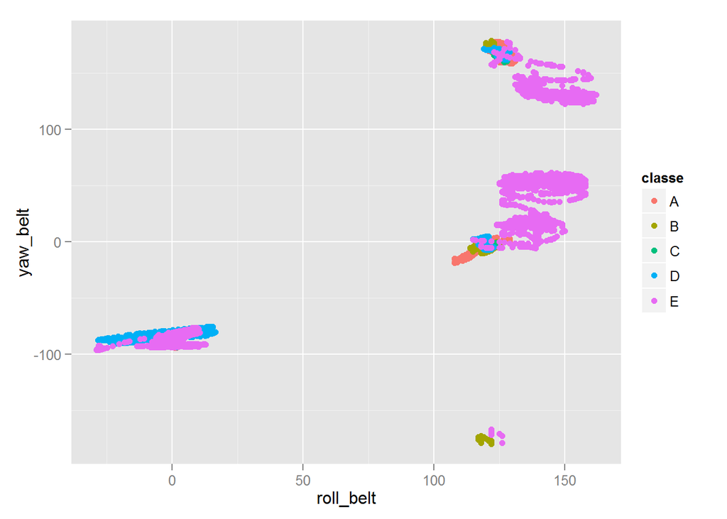

```r
qplot(roll_belt, yaw_belt,colour=classe,data=newTraining)
```

Although these are the top observations, however, not great predictors. Obviously, some bunching can be seen in this plot. The choice of a boosting algorithm is a good choice given the large number of weak predictors. The next plot shows the improved performance using boosting iterations.

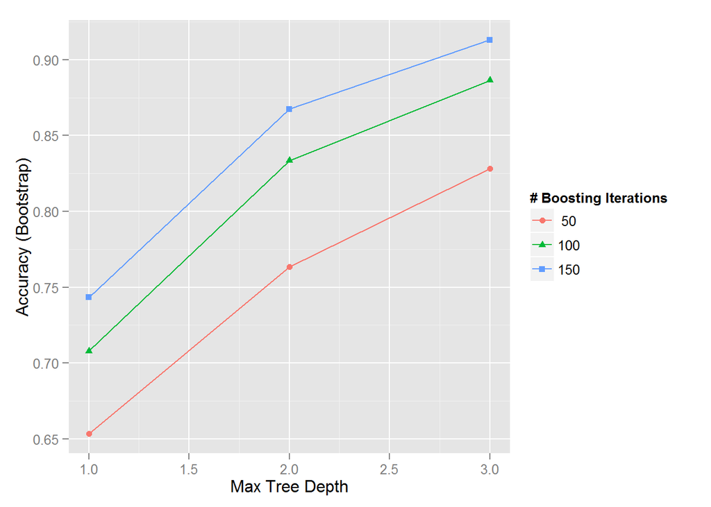

```r
ggplot(modFitA1)
```

```r
predictTesting <- predict(modFitA2, newTesting) #predict newTesting chaged to testing
table(predictTesting, newTesting$classe)
```

```
##
## predictTesting   A   B   C   D   E
##              A 547   8   1   1   1
##              B   2 365   6   0   1
##              C   1   6 332   5   0
##              D   6   0   3 314   2
##              E   2   0   0   1 356
```

#### Prediction Phase

Finally, predict using the original testing set. The results go to the `pml_write_files()` function and stored.

```r
pml.testing <- read.csv("K:/COURSES/JHU_DataScience/PracticalMachineLearning/project/data/pml-testing.csv")
answers <- as.character(predict(modFitA1, pml.testing))
pml_write_files = function(x){
  n = length(x)
  for(i in 1:n){
    filename = paste0("problem_id_",i,".txt")
    write.table(x[i],file=filename,quote=FALSE,row.names=FALSE,col.names=FALSE)
  }
}
pml_write_files(answers)
```